# hw6 Stat139

Callin Switzer

October 19, 2014

# #3

*Ch.6, #23 (Diet Wars)*

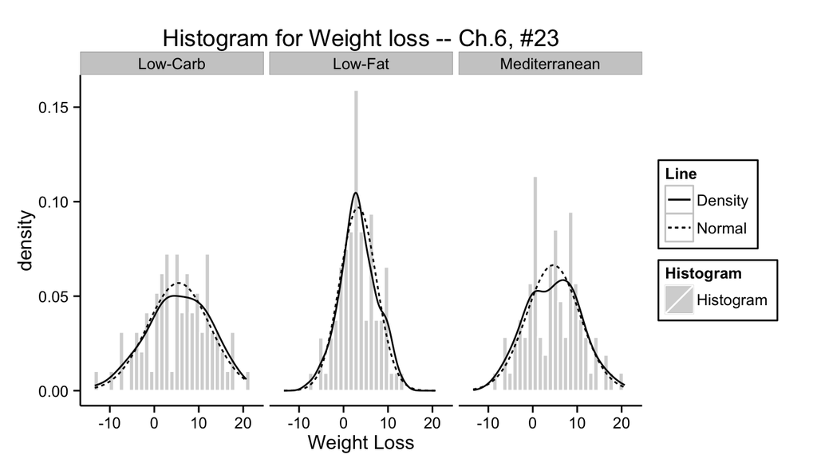

```
## [1] "This comparison of histograms already shows that the groups' variances may not be equal"
```

I wanted to check the assumptions of the ANOVA F-test before using it. It’s assumptions are the following: 1. Normality of populations; 2. Equal population variances for all groups; 3. Independence within each group; 4. Independence between groups; 5. Homogeneity within each group; 6. Random sampling

I plotted the residuals and the Q-Q plot below to help check these assumptions.

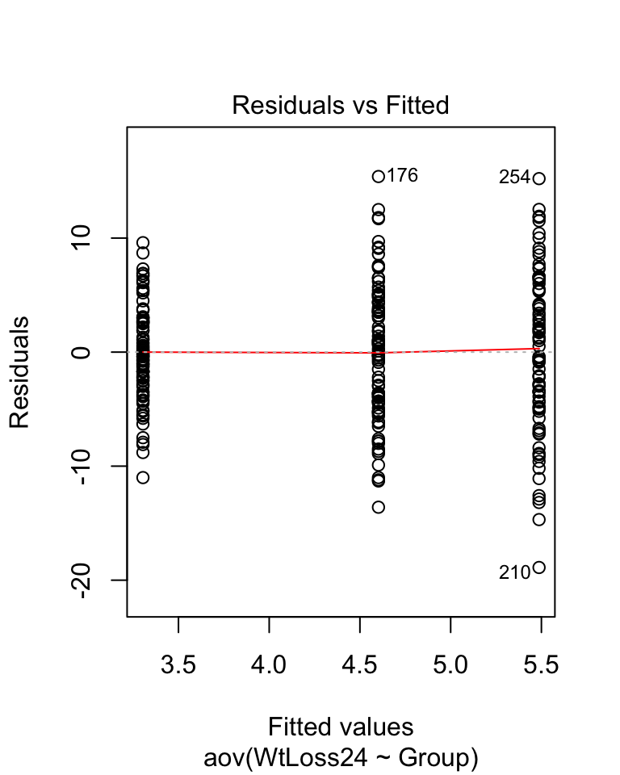

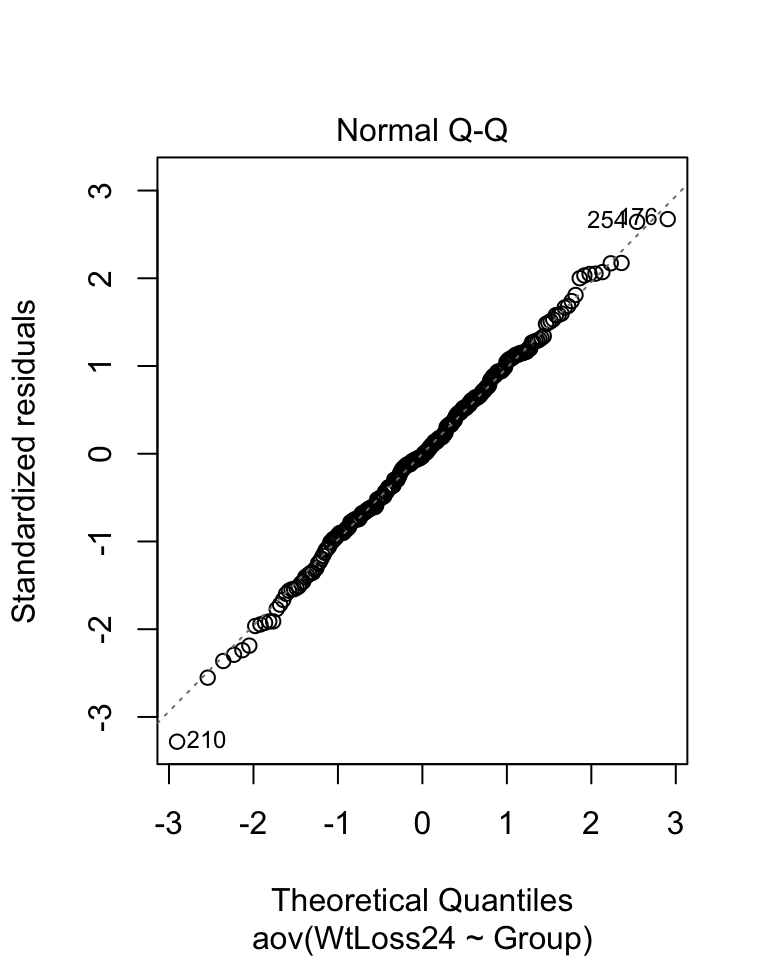

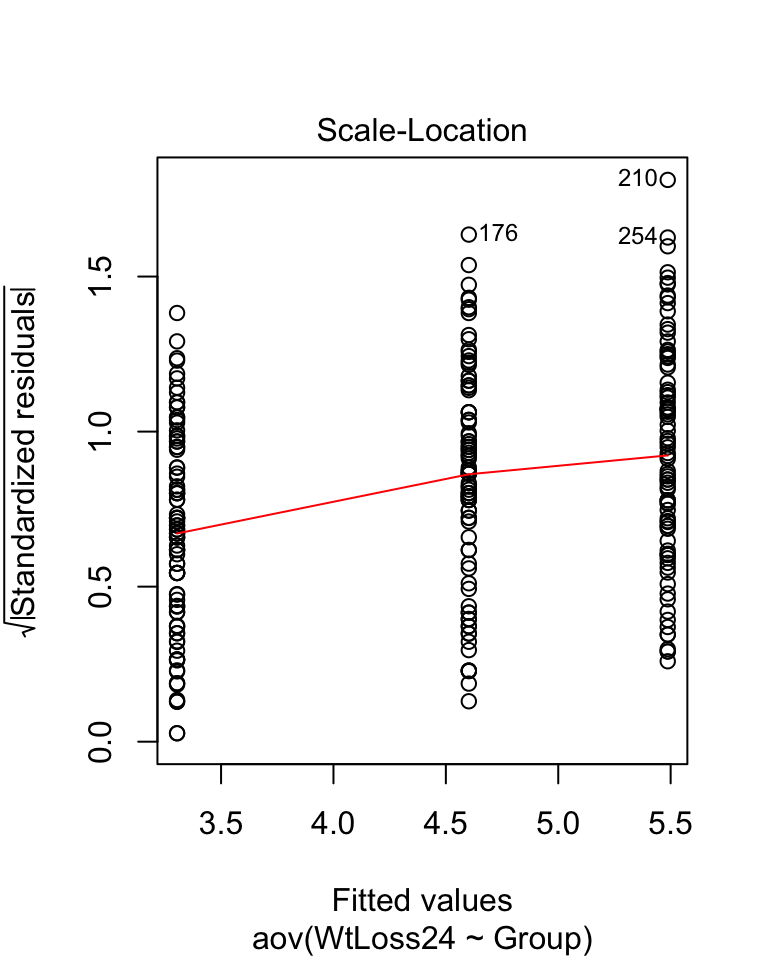

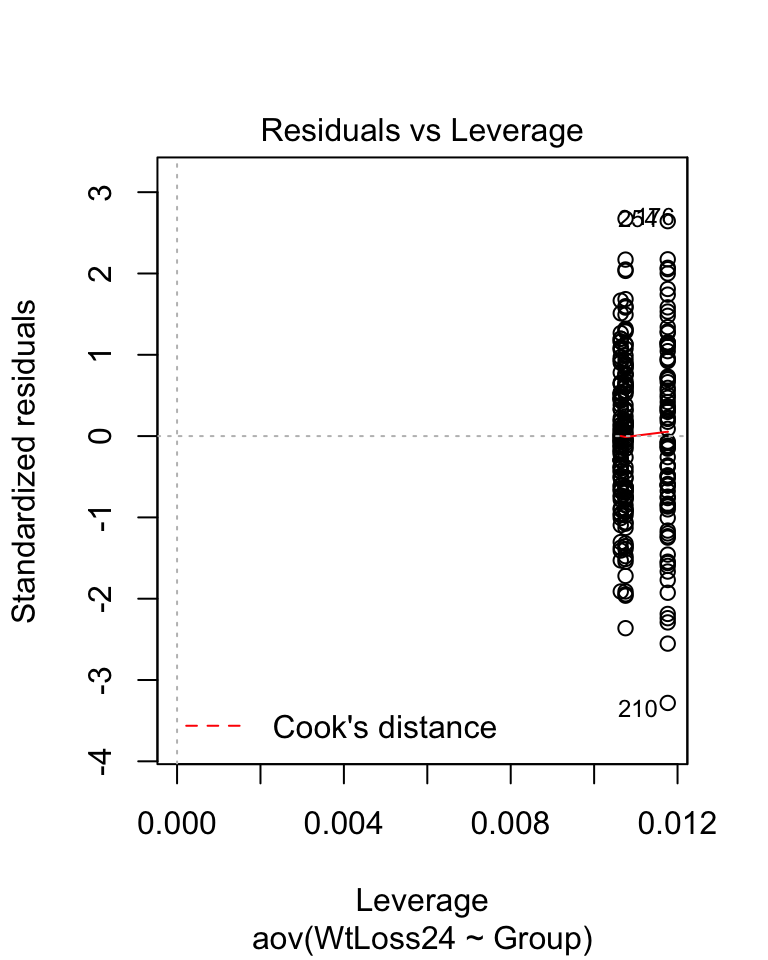

The only assumptions that might not be met are the following: Random sampling wasn’t used, and the populations might not have equal variances. Because the variances look different, I’ll use Kruskal-Wallis test to see if I get the same answer.

Here is the summary of the anova F-test

```
##              Df Sum Sq Mean Sq F value Pr(>F)
## Group         2    217   108.4    3.24  0.041 *
## Residuals   269   9014    33.5
## ---
## Signif. codes:  0 '***' 0.001 '**' 0.01 '*' 0.05 '.' 0.1 ' ' 1
```

Here is the summary of the Kruskal-Wallis test

```
##
##  Kruskal-Wallis rank sum test
##
## data:  list(LC, LF, ME)
## Kruskal-Wallis chi-squared = 6.606, df = 2, p-value = 0.03678
```

Both the Kruskal-Wallis test and the ANOVA F-test give significant results. From the ANOVA F-test, the hypotheses are these:

H0: All groups have the same mean HA: At least one group has a different mean from the others

We have found evidence that at least one group mean is different from the others. To find which group is different, I will use the Tukey-Kramer method (since sample sizes are different). The Tukey-Kramer method ensures that the familywise error rate stays at a constant rate, which I will use 0.05. Here is the R output for the pairwise comparison, using the Tukey-Kramer method for multiple comparisons (with a plot included):

```
##   Tukey multiple comparisons of means
##     95% family-wise confidence level
##
## Fit: aov(formula = WtLoss24 ~ Group, data = lunch)
##
## $Group
##                                   diff     lwr     upr  p adj
## Low-Fat-Low-Carbohydrate       -2.1828 -4.2248 -0.1408 0.0329
## Mediterranean-Low-Carbohydrate -0.8849 -2.9321  1.1623 0.5657
## Mediterranean-Low-Fat           1.2979 -0.6974  3.2932 0.2771
```

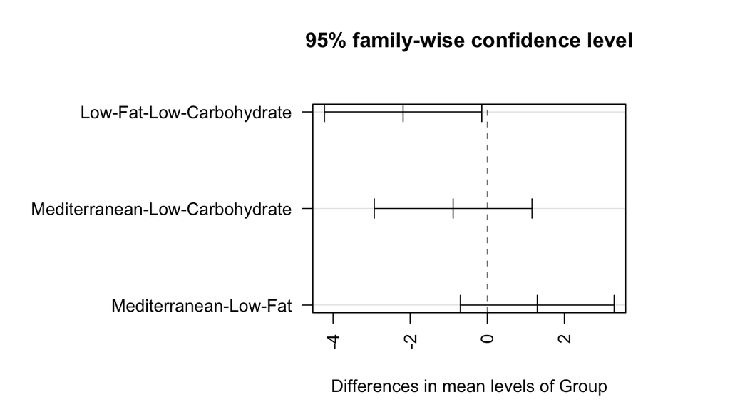

When I don’t correct for multiple comparisons, I get this:

```
##
##  Pairwise comparisons using t tests with pooled SD
##
## data:  lunch$WtLoss24 and lunch$Group
##
##               Low-Carbohydrate Low-Fat
## Low-Fat       0.012            -
## Mediterranean 0.309            0.126
##
## P value adjustment method: none
```

The p-values are slightly lower, but there is not a difference in which groups are significantly different from one another (i.e. the only two groups that are estimated to have significantly different means are low-fat and low-carbohydrate)

In summary, I used the Tukey-Kramer procedure to compare all possible pairwise means. From this test, I rejected the hypothesis that low-fat and low-carbohydrate diets have the same mean weight loss. I found evidence that low carbohydrate diets are estimated to have higher mean weight loss than low-fat diets.

# #4

The difference between planned and unplanned comparisons is as follows: planned comparisons were planned by the researcher before looking at the data. Unplanned comparisons are those which the researcher has decided to investigate after collecting and looking at the data.

Summary of “No Adjustments Are Needed for Multiple Comparisons”: Rothman claims that the problem of multiple comparisons is based on two presumptions: 1. Chance can and does cause unusual findings and 2. No one would want to investigate something caused by chance. He goes on to say that both of these presumptions are false. He claims that when we correct for multiple comparisons, wer’re assuming that a “universal” null hypothesis is true. This hypothesis is that all associations we observe reflect random variation. He goes on to say that we should not be penalized for peeking at new data.

How does Dallal respond to the Rothman’s argument? Dallal responds by essentially condending that experiments are random – He says when you do multiple comparisons, you are increasing the familywise type I error. He responds to Rothman’s argument by saying that it is shortsighted. He claims that experiments with multiple comparisons are fundamentally different from multiple experiments with two groups. Multiple experiments can test targeted hypotheses, while all pairwise comparisons in a single experiment produce more undertainty. He says that multiple comparisons are tricky, and we can sometimes use a combination of Fisher’s LSD and Tukey’s HSD to guide our analyses.